# Snowshoe Hare: Exploratory Report

Russell Fager

11/5/2021

### 2. Juvenile Snowshoe Hare Annual Trap Counts.

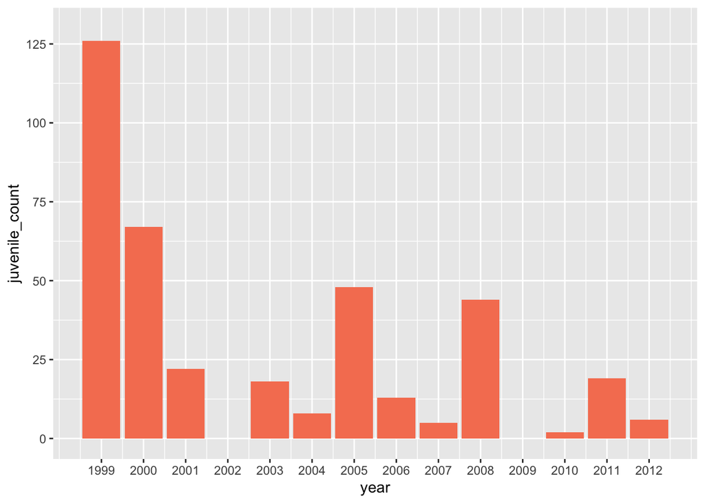

The minimum trap count is 2 and the max trap count is 126, which illustrates the declining trend in juvenile counts during this time frame. The mean trap count is 31.5 and the median is 18.5. For future analyses, the number of traps and time devoted to trapping should be standardized in order to avoid inconsistencies or potential skews in the data.

### Juvenile Snowshoe Hare Weight Visualization

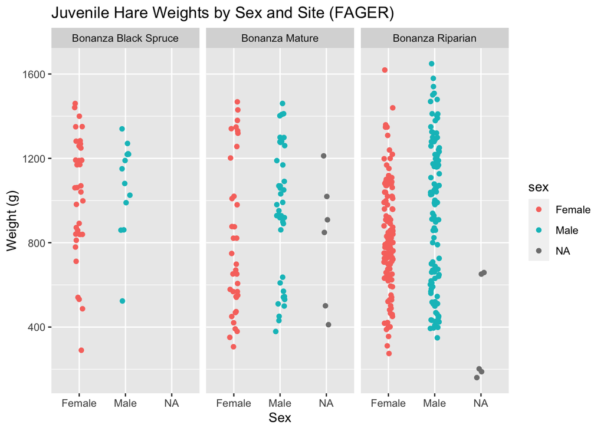

**Figure 2: Weight distribution of male and female snowshoe hares across 3 sites.**

This visualization shows that male and female juvenile snowshoe hare weights are similarly distributed. It also shows that the Bonanza Riparian site had more trappings, which could indicate that there is a larger snowshoe hare population at that site. The second highest trappings occurred at the Mature site, followed by the Black Spruce site. Summary statistics for this data are provided below.

**Table 1: Summary Statistics of Juvenile Snowshoe Hare Weight (male vs female)**

Summary Statistics of Juvenile Hare Weights

| Sex | Mean Weight (g) | Standard deviation | Sample Size |
| --- | --- | --- | --- |
| Female | 855.39 | 292.25 | 200 |
| Male | 945.86 | 333.22 | 163 |
| NA | 614.55 | 357.59 | 15 |

On average, male juvenile hares are 90.47 grams heavier than female hares. In the two sample t-test there is a p-value of 0.0070933, which means that if our samples were drawn from populations with the same mean, there is a 0.7 percent chance of getting our observed results by random chance. Since the p-value is less than 5%, we can reject the null hypothesis that these populations are the same and can conclude that there is a statistically significant difference between these populations. Cohen’s D (0.29) however, shows that the difference in mean between male and female hares is small-medium (small effect size). In conclusion, even though our p-value shows a statistical significance between the mean weight of male and female juvenile snowshoe hares, the actual difference is minimal, which is supported by the small Cohen’s D value (0.29), and nominal difference in means (males are 9% larger on average).

### Juvenile Snowshoe Hare Weight & Hind Foot Length.

This section explores the relationship between juvenile snowshoe hare hind foot length (mm) and weight (g).

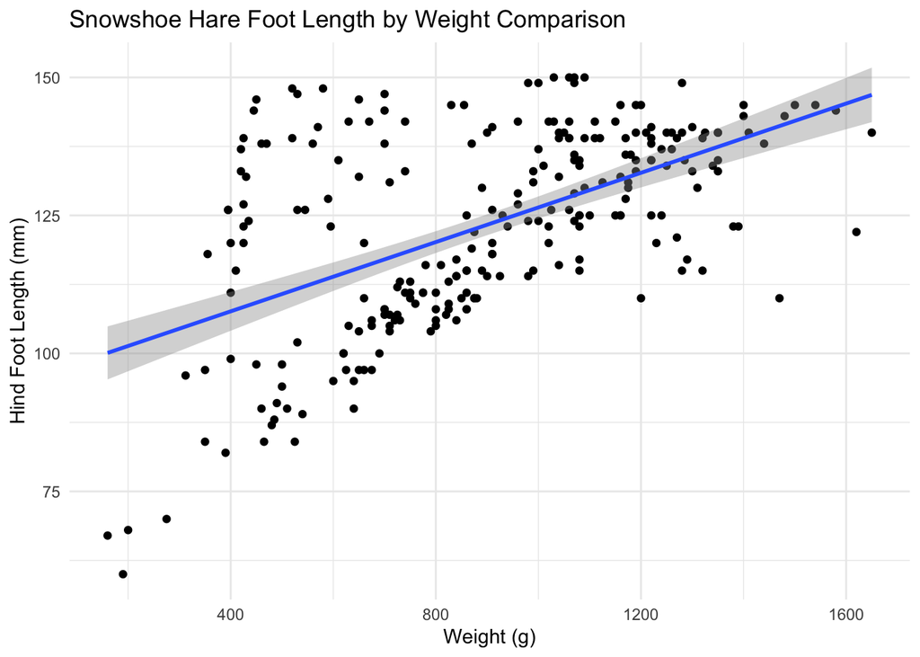

**Figure 4. Linear regression showing how juvenile snowshoe hare weight changes with respect to hind foot length.**

The regression shows that on average for every 1mm increase in hind foot length we expect a 9.52 gram increase in hare weight. Because this relationship cannot be completely exponential, we must also consider the range when using this coefficient. Also if we consider the R squared value 0.299 it shows that only 29.9 percent of variance in the dependent variable (hind foot length) is predictable from the independent variable (weight). This suggests that a linear regression is not the best fit for this data.

### Citations

Data citation: Kielland, K., F.S. Chapin, R.W. Ruess, and Bonanza Creek LTER. 2017. Snowshoe hare physical data in Bonanza Creek Experimental Forest: 1999-Present ver 22. Environmental Data Initiative. https://doi.org/10.6073/pasta/03dce4856d79b91557d8e6ce2cbcdc14